# 8.1. Tidy Data

Tidy data is a standard way of mapping the meaning of a dataset to its structure. A dataset is messy or tidy depending on how rows, columns and tables are matched up with observations, variables and types. In tidy data:

- Each variable forms a column
- Each observation forms a row
- Each type of observational unit forms a table cell.

Tidy data makes it easy to do analyses although there are applications where data may be stored in preferred formats (not necessarily tidy by the definition above) for efficiency reasons. The reason for a lot of data wrangling and cleaning is really to create tidy data sets because measured variables become clear and the analysis, easy and straightforward.

Consider an example tibble.

```r
d <- tibble(
    id = 1:4,
    gender = c("M", "F", "F", "M"),
    sbp.trt1 = c(125, 110, 100, 135),
    dbp.trt1 = c(81, 90, 80, 90),
    sbp.trt2 = c(120, 115, 114, 130),
    dbp.trt2 = c(75, 91, 82, 88)
)
d
```

```
## # A tibble: 4 x 6
##      id gender sbp.trt1 dbp.trt1 sbp.trt2 dbp.trt2
##   <int> <chr>     <dbl>    <dbl>    <dbl>    <dbl>
## 1     1 M           125       81      120       75
## 2     2 F           110       90      115       91
## 3     3 F           100       80      114       82
## 4     4 M           135       90      130       88
```

Although five variables are measured for a patient: `id`, `gender`, `sbp`, `dbp`, `treatment` (1 or 2), not all of these in a column by themselves. For example the treatment that the patient got is along columns.

This is not tidy data.

Notice also how complicated it is to compute a simple thing such as the overall average of all systolic pressure measurements.

- We have to find the two columns that relate to systolic pressure measurements
- We would have to sum all the values
- We would have to divide by the number of measurements.

The natural thing we expect to do is apply a function like `mean` to a single column and the above doesn’t fit for this data.

```r
d
```

```
## # A tibble: 4 x 6
##      id gender sbp.trt1 dbp.trt1 sbp.trt2 dbp.trt2
##   <int> <chr>     <dbl>    <dbl>    <dbl>    <dbl>
## 1     1 M           125       81      120       75
## 2     2 F           110       90      115       91
## 3     3 F           100       80      114       82
## 4     4 M           135       90      130       88
```

The natural format is one where have a column for the treatment (`trt`), a column for the type of blood pressure measurement (`sbp` or `dbp`) and a column for the blood pressure value (`bp`). If we have that format, then we can bring the power of `dplyr` and pipes discussed above to compute all kinds of summaries very easily.

Tidying data also makes it easy to produce complex plots as we shall see later.

# 8.1.1. The package `tidyr`

The package `tidyr` (in `tidyverse`) provides some functions to reshaping the data into a form you want. The operative word here is *reshape*!

Note: Package `tidyr` contains function `gather` which also does what I am going to describe below, but it is now deprecated as new improved functions have replaced it.

### Step 1

The `tidyr::pivot_longer` function will take columns in a multiple columns and collapses into key-value pairs. It takes care to duplicate all other columns in the data set. This function is useful when we have have columns that are not variables. (That is certainly the case for us since the columns contain treatment information: `trt1` and `trt2`.)

```r
d %>%
    pivot_longer(cols = c(sbp.trt1, dbp.trt1, sbp.trt2, dbp.trt2),
                 names_to = "trt", values_to = "bp")
```

```
## # A tibble: 16 x 4
##       id gender trt         bp
##    <int> <chr>  <chr>    <dbl>
##  1     1 M      sbp.trt1   125
##  2     1 M      dbp.trt1    81
##  3     1 M      sbp.trt2   120
##  4     1 M      dbp.trt2    75
##  5     2 F      sbp.trt1   110
##  6     2 F      dbp.trt1    90
##  7     2 F      sbp.trt2   115
##  8     2 F      dbp.trt2    91
##  9     3 F      sbp.trt1   100
## 10     3 F      dbp.trt1    80
## 11     3 F      sbp.trt2   114
## 12     3 F      dbp.trt2    82
## 13     4 M      sbp.trt1   135
## 14     4 M      dbp.trt1    90
## 15     4 M      sbp.trt2   130
## 16     4 M      dbp.trt2    88
```

The above invocation asks `pivot_longer` to take the four blood pressure columns and convert them into key-value pairs. The key column will be named `trt` and the value column will be given the name `bp`.

We can see this clearly by looking at the original data and after it has been gathered, side-by-side.

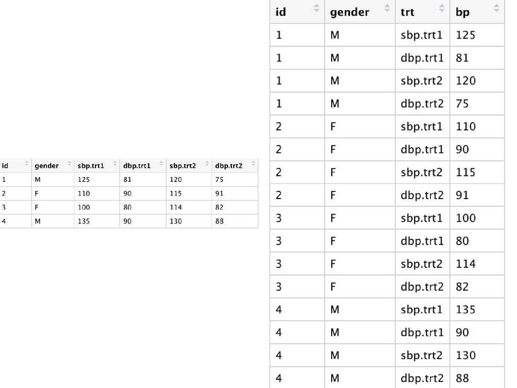

Notice how `pivot_longer` duplicated the `id` and `gender` columns to keep the data consistent. The order in which the values appear is dictated by the order of the arguments specified in the `pivot_longer` invocation above.

Instead of telling `pivot_longer` which columns to convert to key-value pairs, we can also tell it which columns *not to use*.

Thus, the same effect above could be achieved via:

```r
d %>%
    ## gather all columns but id and gender
    pivot_longer(cols = -c(id, gender), names_to = "trt", values_to = "bp")
```

```
## # A tibble: 16 x 4
##       id gender trt         bp
##    <int> <chr>  <chr>    <dbl>
##  1     1 M      sbp.trt1   125
##  2     1 M      dbp.trt1    81
##  3     1 M      sbp.trt2   120
##  4     1 M      dbp.trt2    75
##  5     2 F      sbp.trt1   110
##  6     2 F      dbp.trt1    90
##  7     2 F      sbp.trt2   115
##  8     2 F      dbp.trt2    91
##  9     3 F      sbp.trt1   100
## 10     3 F      dbp.trt1    80
## 11     3 F      sbp.trt2   114
## 12     3 F      dbp.trt2    82
## 13     4 M      sbp.trt1   135
## 14     4 M      dbp.trt1    90
## 15     4 M      sbp.trt2   130
## 16     4 M      dbp.trt2    88
```

Both forms are very useful.

The `tidyverse` further provides selection facilities (via `tidyselect` package) for specifying columns using patterns for their names, such as `starts_with`, `ends_with`, `one_of`, `contains`, `matches`, etc. See `?tidyselect::select_helpers` and examples.

Again, the same effect, via a different invocation.

```r
d %>%
    ## gather all columns that contain the "bp"
    pivot_longer(cols = tidyselect::contains("bp"), names_to = "trt", values_to = "bp")
```

```
## # A tibble: 16 x 4
##       id gender trt         bp
##    <int> <chr>  <chr>    <dbl>
##  1     1 M      sbp.trt1   125
##  2     1 M      dbp.trt1    81
##  3     1 M      sbp.trt2   120
##  4     1 M      dbp.trt2    75
##  5     2 F      sbp.trt1   110
##  6     2 F      dbp.trt1    90
##  7     2 F      sbp.trt2   115
##  8     2 F      dbp.trt2    91
##  9     3 F      sbp.trt1   100
## 10     3 F      dbp.trt1    80
## 11     3 F      sbp.trt2   114
## 12     3 F      dbp.trt2    82
## 13     4 M      sbp.trt1   135
## 14     4 M      dbp.trt1    90
## 15     4 M      sbp.trt2   130
## 16     4 M      dbp.trt2    88
```

What happens when the columns being gathered have different types? Let us see.

```r
d %>%
    pivot_longer(cols = -id , names_to = "trt", values_to = "bp")
```

```
## Error: No common type for `gender` <character> and `sbp.trt1` <double>.
```

This is a difference from how `tidyr::gather` behaves:

```r
d %>% gather(key = key, value = value, -id)
```

```
## # A tibble: 20 x 3
##       id key      value
##    <int> <chr>    <chr>
##  1     1 gender   M
##  2     2 gender   F
##  3     3 gender   F
##  4     4 gender   M
##  5     1 sbp.trt1 125
##  6     2 sbp.trt1 110
##  7     3 sbp.trt1 100
##  8     4 sbp.trt1 135
##  9     1 dbp.trt1 81
## 10     2 dbp.trt1 90
## 11     3 dbp.trt1 80
## 12     4 dbp.trt1 90
## 13     1 sbp.trt2 120
## 14     2 sbp.trt2 115
## 15     3 sbp.trt2 114
## 16     4 sbp.trt2 130
## 17     1 dbp.trt2 75
## 18     2 dbp.trt2 91
## 19     3 dbp.trt2 82
## 20     4 dbp.trt2 88
```

So in `gather`, `key` is character, and `value` is coerced, promoted to a type that can encompass both types of value, which is character.

This is usually not a good idea, but is sometimes is a quick-and-dirty trick for data cleaning.

### Step 2

So we now have a column that has isolated the treatment. However, there is a problem. It has also combined the measurement `sbp`, `dbp` into the treatment column. So we need to separate it out.

Enter the `tidyr::separate` function, which will separate a specified column into several columns.

```r
d %>%
    pivot_longer(cols = tidyselect::contains("bp"), names_to = "trt", values_to = "bp") %>%
    separate(col = trt, into = c("bpType", "trt"))
```

```
## # A tibble: 16 x 5
##       id gender bpType trt      bp
##    <int> <chr>  <chr>  <chr> <dbl>
##  1     1 M      sbp    trt1    125
##  2     1 M      dbp    trt1     81
##  3     1 M      sbp    trt2    120
##  4     1 M      dbp    trt2     75
##  5     2 F      sbp    trt1    110
##  6     2 F      dbp    trt1     90
##  7     2 F      sbp    trt2    115
##  8     2 F      dbp    trt2     91
##  9     3 F      sbp    trt1    100
## 10     3 F      dbp    trt1     80
## 11     3 F      sbp    trt2    114
## 12     3 F      dbp    trt2     82
## 13     4 M      sbp    trt1    135
## 14     4 M      dbp    trt1     90
## 15     4 M      sbp    trt2    130
## 16     4 M      dbp    trt2     88
```

Nice, except how did `separate` know to separate `sbp.trt1` into `sbp` and `trt1`? In other words, how did it know what to use as a separator?

By default, `separate` uses all non-alphanumeric characters as separators and period is one of them. In case your data set has some other separater, that can be specified using the `sep` argument to `separate`.

```r
d %>%
    pivot_longer(cols = tidyselect::contains("bp"), names_to = "trt", values_to = "bp") %>%
    separate(col = trt, into = c("bpType", "trt")) ->
    tidyD
```

Instead of using `separate`, we can also do the entire thing in one fell swoop.

```r
d %>%
    pivot_longer(cols = tidyselect::contains("bp"),
                 names_to = c("bpType", "trt"),
                 values_to = "bp",
                 names_pattern = "([a-z]+)\\.([a-z]+[1-2])")
```

```
## # A tibble: 16 x 5
##       id gender bpType trt      bp
##    <int> <chr>  <chr>  <chr> <dbl>
##  1     1 M      sbp    trt1    125
##  2     1 M      dbp    trt1     81
##  3     1 M      sbp    trt2    120
##  4     1 M      dbp    trt2     75
##  5     2 F      sbp    trt1    110
##  6     2 F      dbp    trt1     90
##  7     2 F      sbp    trt2    115
##  8     2 F      dbp    trt2     91
##  9     3 F      sbp    trt1    100
## 10     3 F      dbp    trt1     80
## 11     3 F      sbp    trt2    114
## 12     3 F      dbp    trt2     82
## 13     4 M      sbp    trt1    135
## 14     4 M      dbp    trt1     90
## 15     4 M      sbp    trt2    130
## 16     4 M      dbp    trt2     88
```

This is often more efficient, at the slight cost of readability.

# 8.1.2. Apropos Keys and Values

The idea of organizing data using key-value pairs is fundamental and ubiquitous in programming and data science. In fact, one can go full monty and organize any data element this way. Databases that organize most of this data this way, are called [Entity-Attribute-Value (EAV)](https://en.wikipedia.org/wiki/Entity%E2%80%93attribute%E2%80%93value_model) databases.

In such databases, the tables are very skinny, essentially three columns: - what is being measured (the entity) - what attribute of the entity is being measured (the attribute) - what value does that attribute have (the value)

The advantage is that the organization is very general, flexible, efficient and sparse. However there are disadvantages as well.

Since one essentially has a large duffel-bag where you can shove everything, retreiving an entity value involves a search and then possible type conversion everytime, which can be expensive and hard to manage.

So the functions in `tidyr` make it easy to produce such long skinny *tidy* data that make summarizing operations easier.

# 8.1.3. Summaries

The tidiness makes it very easy to compute summaries etc.

1. Mean systolic blood pressure for all patients

```r
library(dplyr)
tidyD %>%
    filter(bpType == "sbp") %>%
    select(bp) %>%
    summarize(meanSBP = mean(bp))
```

```
## # A tibble: 1 x 1
##   meanSBP
##     <dbl>
## 1    119.
```

2. Mean systolic blood pressure by treatment

```r
tidyD %>%
    group_by(trt) %>%
    filter(bpType == "sbp") %>%
    select(bp) %>%
    summarize(meanSBP = mean(bp))
```

```
## # A tibble: 2 x 2
##   trt   meanSBP
##   <chr>   <dbl>
## 1 trt1     118.
## 2 trt2     120.
```

3. Mean blood pressure by treatment, by gender, by type

```r
tidyD %>%
    group_by(trt, gender, bpType) %>%
    select(bp) %>%
    summarize(meanSBP = mean(bp))
```

```
## # A tibble: 8 x 4
## # Groups:   trt, gender [4]
##   trt   gender bpType meanSBP
##   <chr> <chr>  <chr>    <dbl>
## 1 trt1  F      dbp       85
## 2 trt1  F      sbp      105
## 3 trt1  M      dbp       85.5
## 4 trt1  M      sbp      130
## 5 trt2  F      dbp       86.5
## 6 trt2  F      sbp      114.
## 7 trt2  M      dbp       81.5
## 8 trt2  M      sbp      125
```

# 8.1.4. Further Facilities

The package `tidyr` provides functions such as

- `extract` which also turns each group into a new column, with facilities for type conversion
- `unite` which is the complement of `separate` which combines multiple columns into 1, etc.

Use `library(help=tidyr)` to see all the exported functions and also to see vignettes.

# 8.1.5. Discussion

We saw how data transformation may be needed for analysis.

- The series of transformations of a data set in order to produce an analyzable version can be nicely visualized as a pipleline
- The package `dplyr` provides some nice verbs to aid in the transformations and analysis
- The verbs in `dplyr` may be applied uniformly to data in R or structures in R that are backed by remote data (i.e. data in databases)
- Tidy data makes it easy to analyze data, especially using `dplyr` verbs. The package `tidyr` provides several functions to make this possible. A really nice large example using [WHO lung data](http://r4ds.had.co.nz/tidy-data.html#case-study) is discussed in Wickham and Gorlemund’s books *R for Data Science*. We urge you to read it.
- Tidy data works well with `ggplot` visualization tools. We shall see this shortly.

By combining all these packages, one can tackle many of the data-related tasks and produce data that can be analyzed.

# 8.1.6. Resources

- [Case study of WHO lung data](http://r4ds.had.co.nz/tidy-data.html#case-study)
- Help pages for `tidyr`, `tidyselect` packages.